# Generating from Logistic Regression Models

Bryan Keller

2023-02-07

## Logistic Regression for Dichotomous Outcomes

Assume, without loss of generality, that a dichotomous outcome variable is coded as 0/1. Our goal is to specify a probability model for
$$\begin{align*}
\text{Pr}(Y = 1 | X_1, X_2, \ldots, X_p).
\end{align*}$$

In linear regression we use a linear model in the covariates:
$$\begin{align*}
E[Y_i = y_i | {X_1}_i, {X_2}_i, \ldots, {X_p}_i] = \beta_0 + \beta_1 {X_{1}}_i + \beta_2 {X_{2}}_i + \cdots + \beta_p {X_{p}}_i + \epsilon_i,
\end{align*}$$

where $\epsilon_i \stackrel{iid}{\sim} N(0, \sigma^2)$. The model above, however, has a range equal for $Y$ to $(-\infty, \infty)$. To restrict the range to $(0,1)$, we need a function $f:(-\infty, \infty) \rightarrow (0,1)$. Ideally, the function will be simple to write, continuous, differentiable, and monotonic. The logistic function is a prime candidate:
$$\begin{align*}
f(t) = \frac{\exp(t)}{1 + \exp(t)}.
\end{align*}$$

Applying the logistic function to the linear expression based on the covariates gives the following three ways of expressing the equation: probability, odds, and logit (log-odds).

$$\begin{align*}
\text{Pr}(Y = 1 | X_1, X_2, \ldots, X_p) &= \frac{\exp(\beta_0 + \beta_1 X_{1} + \beta_2 X_{2} + \cdots + \beta_p X_{p})}{1 + \exp(\beta_0 + \beta_1 X_{1} + \beta_2 X_{2} + \cdots + \beta_p X_{p})} \\
\frac{\text{Pr}(Y = 1 | X_1, X_2, \ldots, X_p)}{1 - \text{Pr}(Y = 1 | X_1, X_2, \ldots, X_p)} &= \exp(\beta_0 + \beta_1 X_{1} + \beta_2 X_{2} + \cdots + \beta_p X_{p}) \\
\log\left(\frac{\text{Pr}(Y = 1 | X_1, X_2, \ldots, X_p)}{1 - \text{Pr}(Y = 1 | X_1, X_2, \ldots, X_p)}\right) &= \beta_0 + \beta_1 X_{1} + \beta_2 X_{2} + \cdots + \beta_p X_{p}
\end{align*}$$

Note that the logit (i.e., the log of the odds of assignment to 1) is linear in the covariates, $X_1, X_2, \ldots, X_p$. Also note that there is no random error term.

## Generating from a Linear Regression Model

The model for OLS multiple regression is given below.

$$\begin{align*}
E[Y_i = y_i | {X_1}_i, {X_2}_i, \ldots, {X_p}_i] = \beta_0 + \beta_1 {X_{1}}_i + \beta_2 {X_{2}}_i + \cdots + \beta_p {X_{p}}_i + \epsilon_i,
\end{align*}$$

Note that the only random variables in the regression equations are the error terms, $\epsilon_i$, which are assumed to be iid random normal with mean 0 and variance $\sigma^2$. We will need to generate the covariates (predictors) somehow as well, but there are no assumptions made about their distributions and they are considered fixed or known. Thus, the first step in generating data from a regression model is to generate the predictors. But, again, no assumptions are made about their distribution, so they may be generated from whatever arbitrary process that makes sense.

One of the most well-known ways to generate numeric multivariate data with a given correlation structure is multivariate normal, so that is often used. That said, it is also very common to see dichotomous predictors in regression. There are a number of ways to generate multivariate data with mixed numeric and dichotmous types. A simple way is to generate all the data from MVN and then dichotomize variables to be 0/1 as needed. A problem with this method is that the process of dichotomization causes an attenuation of correlation. Here is an example.

```r
library(mvtnorm)
set.seed(1637)
s1 <- rmvnorm(n = 2000,
        mean = c(0, 3),
        sigma = matrix(c(1, .6, .6, 1), 2, 2, byrow = TRUE))
round(cor(s1), 2)
```

```
##      [,1] [,2]
## [1,]  1.0  0.6
## [2,]  0.6  1.0
```

```r
s1 <- cbind(s1, ifelse(s1[,1] > mean(s1[,1]), 1, 0))
round(cor(s1), 2)
```

```
##      [,1] [,2] [,3]
## [1,]  1.0 0.60 0.80
## [2,]  0.6 1.00 0.47
## [3,]  0.8 0.47 1.00
```

The numeric variables $X_1$ and $X_2$ are correlated at 0.60. After dichotomizing $X_1$ (call it $D_1$), the correlatino between $D_1$ and $X_2$ is attenuated to 0.47. It is possible to generate multivariate normal data with dichotomized variables while preserving nominal correlations by using polychoric correlations. This approach is implemented in package **BinNor**.

```r
library(BinNor)
cmat <- matrix(c(1, .4, .3, .2, .1, 0,
                 .4, 1, .4, .3, .2, .1,
                 .3, .4, 1, .4, .3, .2,
                 .2, .3, .4, 1, .4, .3,
                 .1, .2, .3, .4, 1, .4,
                 0, .1, .2, .3, .4, 1), 6, 6, byrow = TRUE)
sigma.star <- compute.sigma.star(no.bin = 3,
                              no.nor = 3,
                              prop.vec.bin = c(0.5, 0.3, 0.2),
                              corr.mat = cmat)
```

```
## No problems are detected for the marginal specification of binary variables!
## All correlations are in feasible range!
## No specification problems are detected for the correlation structure!
```

```r
mydata <- jointly.generate.binary.normal(no.rows = 2000,
                                         no.bin = 3,
                                         no.nor = 3,
                                         prop.vec.bin = c(0.5, 0.3, 0.2),
                                         mean.vec.nor = c(0, 0, 10),
                                         var.nor = c(1, 1, 4),
                                         sigma_star = sigma.star$sigma_star,
                                         continue.with.warning=TRUE)
```

```
## No problems are detected for the marginal specification of binary variables!
## No problems are detected for the marginal specification of normal variables!
```

```r
head(mydata)
```

```
##      [,1] [,2] [,3]         [,4]         [,5]     [,6]
## [1,]    0    0    0 -0.431420669  0.245873144 8.835986
## [2,]    1    1    1 -0.737827225  0.602970260 9.516519
## [3,]    0    0    0  0.354553871 -0.004015003 8.595481
## [4,]    1    0    0 -0.003886238  1.242081767 9.494222
## [5,]    0    0    0 -0.411913567 -1.391639991 7.501105
## [6,]    0    0    0  0.564847353 -0.601516700 9.430338
```

```r
round(cor(mydata), 2)
```

```
##      [,1] [,2] [,3] [,4] [,5] [,6]
## [1,] 1.00 0.42 0.30 0.24 0.12 0.03
## [2,] 0.42 1.00 0.38 0.29 0.16 0.09
## [3,] 0.30 0.38 1.00 0.41 0.28 0.20
## [4,] 0.24 0.29 0.41 1.00 0.39 0.30
## [5,] 0.12 0.16 0.28 0.39 1.00 0.39
## [6,] 0.03 0.09 0.20 0.30 0.39 1.00
```

So now back to data generation for a linear regression model.

1. Generate $n \times p$ matrix of predictor variables (e.g., using **BinNor**).
2. Multiply each predictor by its associated regression coefficient after adding a column of 1s for the intercept.
3. Add the predictor vectors together.
4. Generate the $n \times 1$ vector of random errors.
5. Add the errors to the sum of the scaled predictors.

# Step 1 - Generate the predictors

```r
set.seed(9289)
X <- rmvnorm(n = 500,
             mean = c(1.17, 7.38, 53.11, 104.46),
             sigma = matrix(c(0.37, 1.58, -3.24, -21.29,
                              1.58, 13.63, -14.55, -103.41,
                              -3.24, -14.55, 65.24, 153.99,
                              -21.29, -103.41, 153.99, 2702.01),
                            nrow = 4, ncol = 4, byrow = TRUE))
head(X)
```

```
##           [,1]      [,2]     [,3]      [,4]
## [1,] 1.3401794  7.708016 42.46440  98.43666
## [2,] 0.5795090  6.293396 62.89616  77.01820
## [3,] 1.5990095 10.049954 45.45428 123.48471
## [4,] 0.2599557  6.940745 62.43697 174.10228
## [5,] 0.9022353  7.015060 57.64271 157.29298
## [6,] 1.7745860  9.110670 46.87061  57.58498
```

```r
round(cov(X), 2)
```

```
##        [,1]   [,2]   [,3]    [,4]
## [1,]   0.37   1.65  -3.16  -21.48
## [2,]   1.65  14.20 -16.04  -98.94
## [3,]  -3.16 -16.04  63.99  143.62
## [4,] -21.48 -98.94 143.62 2756.89
```

```r
apply(X, 2, mean)
```

```
## [1]   1.169396   7.257422  53.034532 103.744241
```

# Steps 2-5 - Multiply predictors by regression coefficients, add them up, and generate and add random error.

```r
X_aug <- cbind(1, X) # Add column of 1s for intercept.
coefs <- matrix(c(70.5, -.18, -.27, .04, -.008), nrow = 5, ncol = 1)
set.seed(1281)
Y <- X_aug %*% coefs + rnorm(500, 0, .75) # Matrix multiply to multiply and add up.
df <- data.frame(Y, X)
head(df)
```

```
##          Y        X1        X2       X3        X4
## 1 70.45704 1.3401794  7.708016 42.46440  98.43666
## 2 70.93997 0.5795090  6.293396 62.89616  77.01820
## 3 68.76062 1.5990095 10.049954 45.45428 123.48471
## 4 69.09467 0.2599557  6.940745 62.43697 174.10228
## 5 69.92733 0.9022353  7.015060 57.64271 157.29298
## 6 71.77606 1.7745860  9.110670 46.87061  57.58498
```

```r
cor(df)
```

```
##             Y         X1         X2         X3         X4
## Y   1.0000000 -0.5757364 -0.7933853  0.5917232  0.2487687
## X1 -0.5757364  1.0000000  0.7213831 -0.6511262 -0.6736315
## X2 -0.7933853  0.7213831  1.0000000 -0.5319660 -0.4999850
## X3  0.5917232 -0.6511262 -0.5319660  1.0000000  0.3419481
## X4  0.2487687 -0.6736315 -0.4999850  0.3419481  1.0000000
```

Put it together in a function for convenient data generation.

```r
dat_gen <- function(n) {
  X <- rmvnorm(n = n,
             mean = c(1.17, 7.38, 53.11, 104.46),
             sigma = matrix(c(0.37, 1.58, -3.24, -21.29,
                              1.58, 13.63, -14.55, -103.41,
                              -3.24, -14.55, 65.24, 153.99,
                              -21.29, -103.41, 153.99, 2702.01),
                            nrow = 4, ncol = 4, byrow = TRUE))
  X_aug <- cbind(1, X)
  coefs <- matrix(c(70.5, -.18, -.27, .04, -.008), nrow = 5, ncol = 1)
  Y <- X_aug %*% coefs + rnorm(100, 0, .75)
  df <- data.frame(X, Y)
  return(df)
}
```

As a check, generate some data and fit the a linear regression model. Looks good.

```r
set.seed(7600)
dat <- dat_gen(n = 1000)
lm1 <- lm(Y ~ ., data = dat)
summary(lm1)
```

```
##
## Call:
## lm(formula = Y ~ ., data = dat)
##
## Residuals:
##      Min       1Q   Median       3Q      Max
## -2.32423 -0.45542  0.05253  0.54573  1.57510
##
## Coefficients:
##               Estimate Std. Error t value Pr(>|t|)
## (Intercept) 70.2590021  0.3020803 232.584   <2e-16 ***
## X1          -0.1493259  0.0760306  -1.964   0.0498 *
## X2          -0.2740951  0.0090343 -30.339   <2e-16 ***
## X3           0.0417184  0.0040086  10.407   <2e-16 ***
## X4          -0.0074034  0.0006359 -11.643   <2e-16 ***
## ---
## Signif. codes:  0 '***' 0.001 '**' 0.01 '*' 0.05 '.' 0.1 ' ' 1
##
## Residual standard error: 0.7603 on 995 degrees of freedom
## Multiple R-squared:  0.6873, Adjusted R-squared:  0.6861
## F-statistic: 546.9 on 4 and 995 DF,  p-value: < 2.2e-16
```

## Generating from a Logistic Regression Model

There are two big differences when generating data from a logistic model. First, the outcome is dichotomous, not numeric. Second, there is no normally distributed error term. In fact, there is no error term in the model at all. The randomness comes in the fact that we are modeling the probability of $Y = 1$ given the covariates. Then, to convert that probability, $p$ to a 0/1, a random draw from a Bernoulli($p$) does it.

To generate probabilities (also called propensity scores in this context) from this model, transform to the probability scale. Let $\pi = P(Y = 1| X_1, X_2, \ldots, X_p)$ and let $\eta = \beta_0 + \beta_1 {X_{1}} + \beta_2 {X_{2}} + \cdots + \beta_p {X_{p}}$. Then,
$$\begin{align*}
log\left(\frac{\pi}{1-\pi}\right) &= \eta \\
\frac{\pi}{1-\pi} &= e^\eta \\
\frac{1-\pi}{\pi} &= e^{-\eta} \\
\frac{1}{\pi} &= 1 + e^{-\eta} \\
\pi &= (1 + e^{-\eta})^{-1} \\
\end{align*}$$

Once again, the first step is to generate the predictors.

```r
set.seed(3682)
X <- rmvnorm(n = 500,
             mean = c(1.17, 7.38, 53.11, 104.46),
             sigma = matrix(c(0.37, 1.58, -3.24, -21.29,
                              1.58, 13.63, -14.55, -103.41,
                              -3.24, -14.55, 65.24, 153.99,
                              -21.29, -103.41, 153.99, 2702.01),
                            nrow = 4, ncol = 4, byrow = TRUE))
```

Next, generate the probabilities using the probability model.

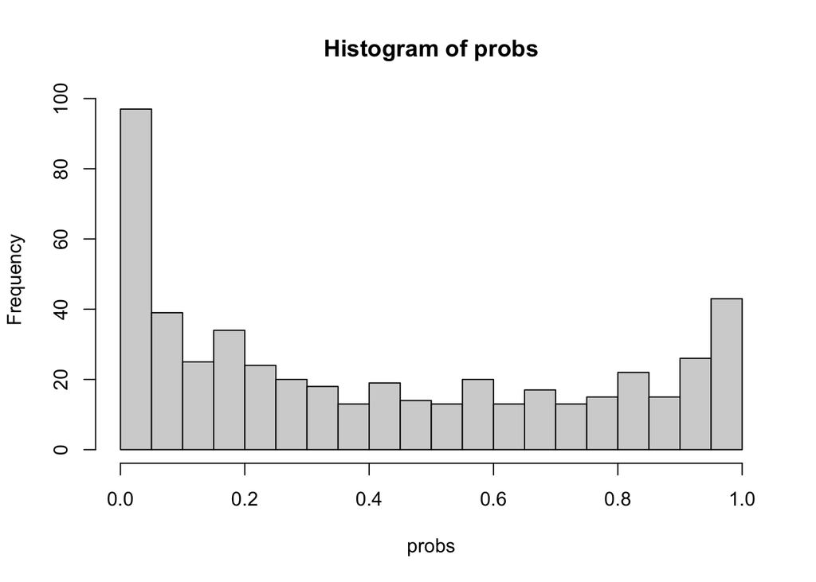

```r
X_aug <- cbind(1, X)
coefs <- matrix(c(-0.32, .10, -.67, .12, -.02), nrow = 5, ncol = 1)
eta <- X_aug %*% coefs
probs <- (1 + exp(-eta))^(-1)
hist(probs, breaks = 30)
```

Finally, use the probabilities to generate 0/1 via Bernoulli draws or thresholding Uniform(0,1) draws, etc.

```r
set.seed(6417)
Y <- rbinom(n = 500, size = 1, prob = probs)
table(Y)
```

```
## Y
##   0   1
## 290 210
```

As a last step, let’s put it all in a function for data generation.

```r
dat_gen_lr <- function(n) {
  X <- rmvnorm(n = n,
             mean = c(1.17, 7.38, 53.11, 104.46),
             sigma = matrix(c(0.37, 1.58, -3.24, -21.29,
                              1.58, 13.63, -14.55, -103.41,
                              -3.24, -14.55, 65.24, 153.99,
                              -21.29, -103.41, 153.99, 2702.01),
                            nrow = 4, ncol = 4, byrow = TRUE))
  X_aug <- cbind(1, X)
  coefs <- matrix(c(-0.32, .10, -.67, .12, -.02), nrow = 5, ncol = 1)
  eta <- X_aug %*% coefs
  probs <- (1 + exp(-eta))^(-1)
  Y <- rbinom(n = n, size = 1, prob = probs)
  df <- data.frame(X, probs, Y)
  return(df)
}
```

As a check, generate some data and fit a logistic regression model.

```r
set.seed(2612)
dat <- dat_gen_lr(n = 1000)
glm1 <- glm(Y ~ . - probs, data = dat, family = "binomial")
summary(glm1)
```

```
##
## Call:
## glm(formula = Y ~ . - probs, family = "binomial", data = dat)
##
## Deviance Residuals:
##     Min       1Q   Median       3Q      Max
## -2.3872  -0.6151  -0.1660   0.5843   2.9806
##
## Coefficients:
##              Estimate Std. Error z value Pr(>|z|)
## (Intercept) -0.406169   1.143486  -0.355    0.722
## X1           0.019258   0.280563   0.069    0.945
## X2          -0.622391   0.046673 -13.335  < 2e-16 ***
## X3           0.113079   0.016361   6.911 4.80e-12 ***
## X4          -0.017433   0.002568  -6.789 1.13e-11 ***
## ---
## Signif. codes:  0 '***' 0.001 '**' 0.01 '*' 0.05 '.' 0.1 ' ' 1
##
## (Dispersion parameter for binomial family taken to be 1)
##
##     Null deviance: 1354.44  on 999  degrees of freedom
## Residual deviance:  795.04  on 995  degrees of freedom
## AIC: 805.04
##
## Number of Fisher Scoring iterations: 6
```